# Generacion de Variables Aleatoria

Shamuel Manrrique NIP:802400

10/25/2020

# Practica 1

Aplicar el método de la transformación inversa y/o el de aceptación rechazo para construir una función en R que genere datos de la siguientes distribuciones:

5. **Distribución log exponencial-geométrica (Jodra y Jimenez, 2020)**: ´

## Metodo de transformacion Inversa

Para el calculo de la función de densidad usando el metodo de la transformacion inversa es requerido llevar a cabo una serie de calculo matematicos, por practicidad se usa el software Maple. Maple es un paquete matematico multiplataforma, bastante intuitivo que permite resolver multiples problemas matematicos. Aclarado este punto se procede a seguir los siguiente pasos:

1. Se define la funcion de densidad

2. Integramos y simplificamos la funcion de densidad

> (int(Pdf(x, alpha, beta), x = 0 .. t) assuming (0 < alpha, -1 < beta));simplify(%);

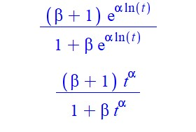

x={0..1},α > 0, β > 0

3. La función de distribución acumulada es:

> Cdf := (x, alpha, beta) -> (beta + 1)*x^alpha/(1 + beta*x^alpha)

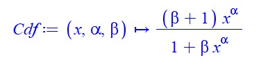

x={0..1},α > 0, β > 0

4. Se calcula la función inversa de la función de distribución acumulada y se simplifica

> solve(Cdf(x,alpha,beta)=u,x);simplify(%);

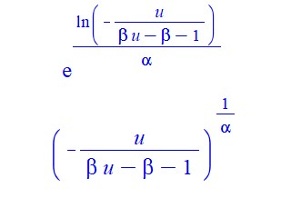

x={0..1},α > 0, β > 0

5. La función inversa de F o función cuantil es:

> Q := (u, alpha, beta) -> (-u/(beta*u - beta - 1))^(1/alpha)

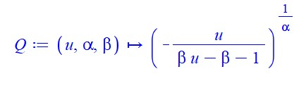

x={0..1},α > 0, β > 0

6. Una vez calculada la funcion inverda se procede a programar en R una funcion para crear de forma automatizada muestras aleatorias que siguen la Distribución log exponencial-geométrica (Jodra y Jimenez, 2020).

### Importar librerías necesarias

```r
library("ggplot2")
library("dplyr")         # load
library("RcmdrMisc")
library("nleqslv")       # Resolver sistema ecuaciones lineales/no lineales
```

### Funcion de Distribución log exponencial-geométrica en R

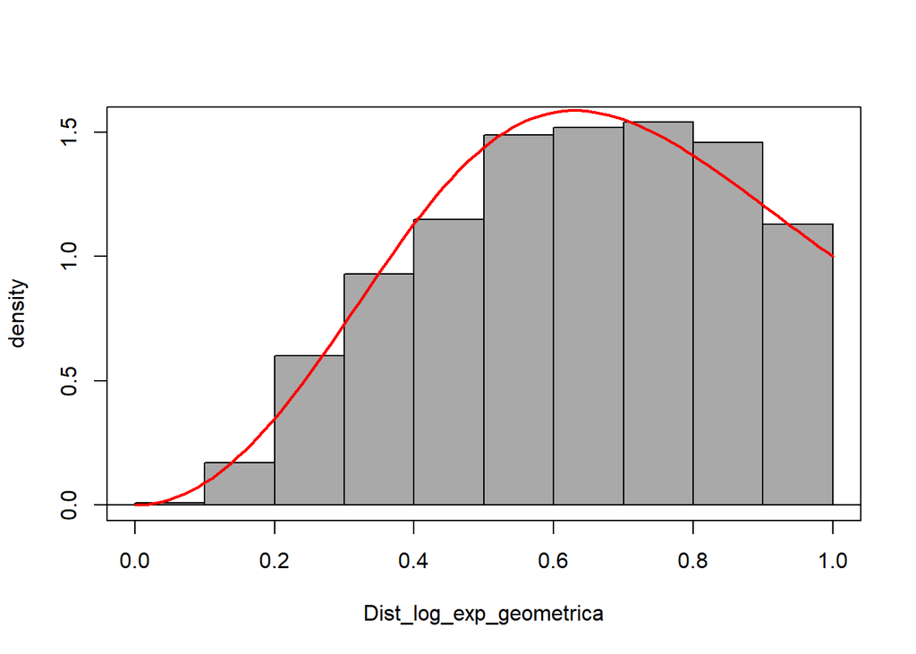

```r
# Definimos función para generar variables aleatoria siguiendo
# la Distribución log exponencial-geométrica (Jodra y Jimenez, 2020)
DatosJoJi <- function(α,β,n){
  # La función recibe los parámetros
  # α -> valor deseado para alpha
  # β -> valor deseado para beta
  # n -> tamaño del vector de variables aleatorias que quieren generar

  # Generar "n" datos uniforme (0,1):
  VectorUnif<-runif(n,0,1)

  # Generar datos de la Distribución log exponencial-geométrica (Jodra y Jimenez, 2020)
  # mediante la función cuantil:

  return ((- VectorUnif /( β * VectorUnif - β - 1))^(1/α))
  #return(((β*(-VectorUnif) - 1)/(β^2*(VectorUnif - 1)))^(1/α))

}

# Definimos la Función de densidad PdfX para validar la correctitud de
# las variables aleatorias creadas con la función DatosJoJi
PdfX<- function(x,n){(α*(1 + β)*x^(α-1))/(1 + β*x^α)^2 }
#PdfX<- function(x) {(α/β)*x^(α-1)*exp(-x^α/β)}


# Declaramos los valores de α,β,n
α=3;
β=2;
n=1000;

# Llamamos la funcion DatosJoJi con sus respectivos parametros
Dist_log_exp_geometrica <- DatosJoJi(α,β,n)

# Graficamos un histograma con las variables obtenidas
Hist(Dist_log_exp_geometrica, scale="density", breaks="Sturges", col="darkgray")

# Añadimos la curva de validacion a la grafica
curve(PdfX(x), from=0, to=1.0, lwd=2, cex = 1.1, col="red",add=TRUE)
```

# Practica 2

Enunciado: Implementar en R, la lección de Métodos de Estimación,sección 1.3. de la siguiente funcion de dencidad:

5. **Distribución log exponencial-geométrica (Jodra y Jimenez, 2020)**:

Para el calulo de los estimadores existen varios metodos, en este caso nos centraremos en el metodo de los momentos y maxima verosimilitud.

## Metodo de los Momentos

Se usar el metodo de los momento para determinar los estimadores alpha y beta, por lo que seguimos los siguientes pasos:

1. Definimos la funcion

> (int(x*Pdf(x, alpha, beta), x = 0 .. 1) assuming (0 < alpha, 0 < beta)); simplify(%);

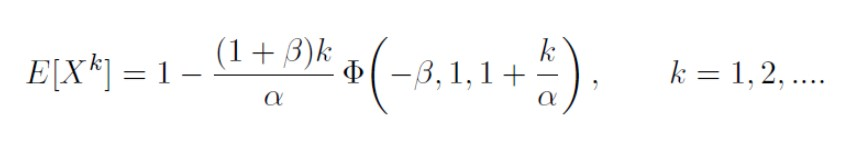

[figure not shown]

## Implementacion en R

```r
# Declaramos los valores de α,β,n
α=2;
β=3;
n=1000; # Numero de datos a generar

VData = DatosJoJi(α,β,n) # generamos n muestras aleatorias con la funcion de distribucion

M1 = mean(VData)   # Momentos muestrales
M2 = mean(VData^2) # Momentos muestrales

# Funcion con el sistema de ecuaciones
SistemaM <- function(x) {
    # ALPHA x[1]
    # BETA x[2]

    y <- numeric(2)
    y[1] <- (x[1]*(x[2]+1) - 1^(x[1]+1)/(1+x[2]*1^(x[1]))^2 )-M1
    y[2] <- (x[1]*(x[2]+1) - 1^(x[1]+2)/(1+x[2]*1^(x[1]))^2 )-M2
    return(y)
}

# Resolver el sistema
xstart <- c(0.1,1)
SolSistem<-nleqslv(xstart, SistemaM, jacobian=TRUE)

# Estimaciones metodo de los momentos:
alphaM<-SolSistem$x[1]; alphaM
```

```
## [1] 0.2600237
```

```r
betaM<-SolSistem$x[2]; betaM
```

```
## [1] 1.251293
```

Estos resultados obtenidos con la funcion implementada permiten comprobar que el método de los momentos no te permite obtener estimadores de los parámetros para esta funcion. Esto se deduce tambien al ver el resultado de los momentos respecto al origen, tanto beta como alpha son argumentos de la función de Lerch y no es posible obtener estimaciones resolviendo el sistema formado por las ecuaciones E[X]-M1=0 y E[X^2]-M2=0, siendo M1 y M2 los momentos muestrales de orden 1 y 2, respectivamente.

# Practica 3

Los estudiantes de Análisis Avanzado de Datos tienen asignado un número que se corresponde con el ejemplo que tienen que implementar en R, de la lección Simulación Monte Carlo, sección 1.5.